# Module 1: Tutorial: Regression

RStudio is able to **simulate the final formatting live**, by switching from “Source” to “Visual” in the task bar above.

# Linear Regression

## Description of data set

The file module1-video_reading.csv contains the following data:

- participant: unique id for each participant
- score_reading: number of points the participant scored in a reading test
- hours_video: average number of hours the participant spends watching video stream (TV, movies, ..) each day.

## Tasks

We first have to install all packages that we need for the following tasks

```r
# only run (by uncommenting) if not already installed (comment out again after installation):
#install.packages('tidyverse', dependencies = T)
#install.packages('mlr3verse', dependencies = T)
```

1. Read the data file module1-video_reading.csv into R and assign it to a variable called “dat”.

```r
dat <- read.csv("module1-video_reading.csv")
head(dat)
```

|  | participant | score_reading | hours_video |
| --- | --- | --- | --- |
| 1 | 1 | 45.0 | 2.8 |
| 2 | 2 | 38.2 | 4.8 |
| 3 | 3 | 58.3 | 2.7 |
| 4 | 4 | 39.8 | 4.0 |
| 5 | 5 | 41.7 | 4.9 |
| 6 | 6 | 51.7 | 1.5 |

2. Draw a scatter plot of “hours_video” and “score_reading”.

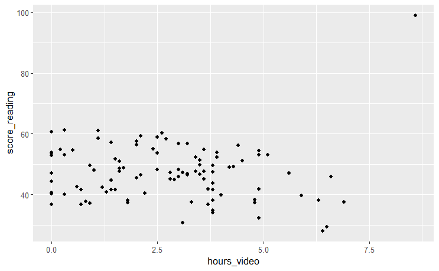

```r
library(ggplot2)

scatter_plot <- ggplot(dat, aes(x=hours_video, y=score_reading)) +
  geom_point()
scatter_plot
```

3. Estimate a linear regression model for “score_reading” as target (dependent variable) and “hours_video” as feature (independent/explanatory variable) using the `lm()` function.

```r
mdl <- lm(score_reading ~ hours_video, data = dat)
summary(mdl)
```

```
Call:
lm(formula = score_reading ~ hours_video, data = dat)

Residuals:
    Min      1Q  Median      3Q     Max
-18.853  -6.666   0.039   6.046  52.424

Coefficients:
            Estimate Std. Error t value Pr(>|t|)
(Intercept)  47.6583     1.6863  28.262   <2e-16 ***
hours_video  -0.1258     0.5089  -0.247    0.805
---
Signif. codes:  0 ‘***’ 0.001 ‘**’ 0.01 ‘*’ 0.05 ‘.’ 0.1 ‘ ’ 1

Residual standard error: 9.387 on 98 degrees of freedom
Multiple R-squared:  0.0006233, Adjusted R-squared:  -0.009574
F-statistic: 0.06112 on 1 and 98 DF,  p-value: 0.8053
```

4. Redo task 3 using the `mlr3verse` package. Does your final model output (applying the `summary()` function on the fitted model object) differ from the one in task 3, which was estimated using `base` R functionality?

```r
library(mlr3verse)
tsk = as_task_regr(score_reading ~ hours_video, data = dat)
mdl = lrn("regr.lm")
mdl$train(tsk)
summary(mdl$model)
```

```
Call:
stats::lm(formula = task$formula(), data = task$data())

Residuals:
    Min      1Q  Median      3Q     Max
-18.853  -6.666   0.039   6.046  52.424

Coefficients:
            Estimate Std. Error t value Pr(>|t|)
(Intercept)  47.6583     1.6863  28.262   <2e-16 ***
hours_video  -0.1258     0.5089  -0.247    0.805
---
Signif. codes:  0 ‘***’ 0.001 ‘**’ 0.01 ‘*’ 0.05 ‘.’ 0.1 ‘ ’ 1

Residual standard error: 9.387 on 98 degrees of freedom
Multiple R-squared:  0.0006233, Adjusted R-squared:  -0.009574
F-statistic: 0.06112 on 1 and 98 DF,  p-value: 0.8053
```

5. Add the regression line from task 4 to the plot from task 2.

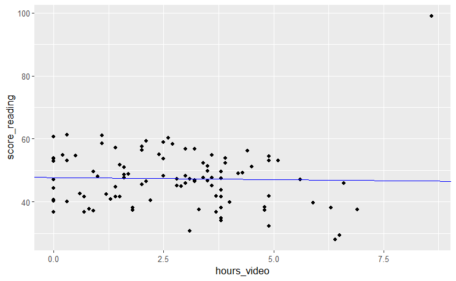

```r
scatter_plot <- scatter_plot +
  geom_abline(aes(intercept = mdl$model$coefficients[['(Intercept)']], slope = mdl$model$coefficients[['hours_video']]), col = 'blue')
scatter_plot
```

```r
# Alternative solution:
#scatter_plot <- ggplot(dat, aes(x=hours_video, y=score_reading)) +
#  geom_point() +
#  geom_smooth(method='lm')
#scatter_plot
```

6. Identify and exclude the outlier, and redo tasks 4 and 5 (i.e., estimate the model again and add the new line to the scatter plot).

```r
dat2 <- dat[dat$participant != 70, ]

# mlr3verse:
task2 = as_task_regr(score_reading ~ hours_video, data = dat2)
mdl2 = lrn("regr.lm")
mdl2$train(task2)
summary(mdl2$model)
```

```
Call:
stats::lm(formula = task$formula(), data = task$data())

Residuals:
     Min       1Q   Median       3Q      Max
-15.7277  -6.3708   0.6861   5.4776  13.3032

Coefficients:
            Estimate Std. Error t value Pr(>|t|)
(Intercept)  49.8564     1.3909  35.844  < 2e-16 ***
hours_video  -1.1383     0.4324  -2.632  0.00987 **
---
Signif. codes:  0 ‘***’ 0.001 ‘**’ 0.01 ‘*’ 0.05 ‘.’ 0.1 ‘ ’ 1

Residual standard error: 7.562 on 97 degrees of freedom
Multiple R-squared:  0.06667,   Adjusted R-squared:  0.05705
F-statistic: 6.929 on 1 and 97 DF,  p-value: 0.009867
```

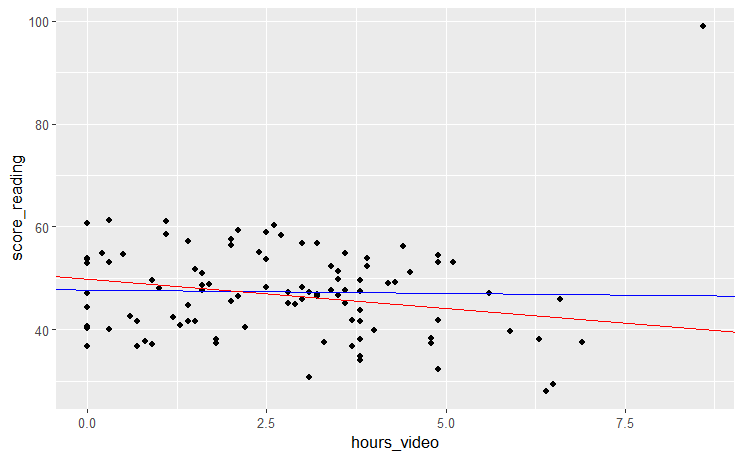

```r
# base R:
#mdl2 <- lm(score_reading ~ hours_video, data = dat2)
#summary(mdl2)

# plotting:
scatter_plot <- scatter_plot +
  geom_abline(aes(intercept = mdl2$model$coefficients[['(Intercept)']], slope = mdl2$model$coefficients[['hours_video']]), col = 'red')
scatter_plot
```

7. What would be the reading score (“score_reading”) of a participant with a video consumption (“hours_video”) equivalent to the 95th percentile as predicted by the model? (Hint: you can use the `predict_newdata()` method on the fitted model object, which behaves similar to the `predict()` function in `base` R)

```r
dat3 <- data.frame('hours_video' = quantile(dat2$hours_video, probs = 0.95))

# mlr3verse:
dat3$score_reading <- mdl2$predict_newdata(newdata = dat3)$response
dat3$score_reading
```

```
[1] 43.09493
```

```r
# base R:
#dat3$score_reading <- predict(mdl2, newdata = dat3)
#dat3$score_reading
```

8. Add the prediction from task 7 to the scatter plot from task 6.

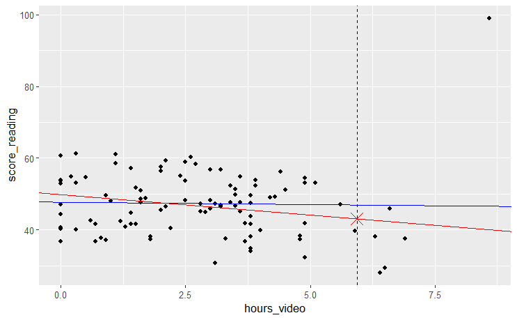

```r
scatter_plot <- scatter_plot +
  geom_vline(data = dat3, aes(xintercept = hours_video), lty = 2) +
  geom_point(data = dat3, color = 'red', size = 5, shape = 'cross')
scatter_plot
```

9. Bonus: What is the effect of “hours_video” on “score_reading” in standardized units? How would you interpret this effect? (Hint: You can use a linear regression model to determine the correlation between “hours_video” and “score_reading”)

```r
# z-standardize data to get standardized regression coefficients
dat2$score_reading_z <- scale(dat2$score_reading)
dat2$hours_video_z <- scale(dat2$hours_video)

# estimate binary regression model
## mlr3verse:
task_z = as_task_regr(score_reading_z ~ hours_video_z, data = dat2)
mdl_z = lrn("regr.lm")
mdl_z$train(task_z)
summary(mdl_z$model)
```

```
Call:
stats::lm(formula = task$formula(), data = task$data())

Residuals:
     Min       1Q   Median       3Q      Max
-2.01967 -0.81810  0.08811  0.70341  1.70832

Coefficients:
                Estimate Std. Error t value Pr(>|t|)
(Intercept)    4.566e-16  9.759e-02   0.000  1.00000
hours_video_z -2.582e-01  9.809e-02  -2.632  0.00987 **
---
Signif. codes:  0 ‘***’ 0.001 ‘**’ 0.01 ‘*’ 0.05 ‘.’ 0.1 ‘ ’ 1

Residual standard error: 0.9711 on 97 degrees of freedom
Multiple R-squared:  0.06667,   Adjusted R-squared:  0.05705
F-statistic: 6.929 on 1 and 97 DF,  p-value: 0.009867
```

```r
## base R:
#mdl_z <- lm(score_reading_z ~ hours_video_z, data = dat2)
#summary(mdl_z)

# comparison to direct correlation testing
cor.test(dat2$hours_video, dat2$score_reading)
```

```
    Pearson's product-moment correlation

data:  dat2$hours_video and dat2$score_reading
t = -2.6323, df = 97, p-value = 0.009867
alternative hypothesis: true correlation is not equal to 0
95 percent confidence interval:
 -0.4335232 -0.0640633
sample estimates:
       cor
-0.2582096
```